# Practical 6: Deep Learning

Author

Ward B. Eiling

# 1 Introduction

In this practical, we will create a feed-forward neural network as well as a convolutional neural network to analyze the famous MNIST dataset.

```r
# install.packages("keras3")
library(keras3)
# install_keras()
```

# 2 Take-home exercises: deep feed-forward neural network

In this section, we will develop a deep feed-forward neural network for MNIST.

## 2.1 Data preparation

**1. Load the built-in MNIST dataset by running the following code. Then, describe the structure and contents of the `mnist` object.**

```r
mnist <- keras3::dataset_mnist()
str(mnist)
```

```
List of 2
 $ train:List of 2
  ..$ x: int [1:60000, 1:28, 1:28] 0 0 0 0 0 0 0 0 0 0 ...
  ..$ y: int [1:60000(1d)] 5 0 4 1 9 2 1 3 1 4 ...
 $ test :List of 2
  ..$ x: int [1:10000, 1:28, 1:28] 0 0 0 0 0 0 0 0 0 0 ...
  ..$ y: int [1:10000(1d)] 7 2 1 0 4 1 4 9 5 9 ...
```

```r
range(mnist$train$x)
```

```
[1]   0 255
```

```r
table(mnist$train$y)
```

```
   0    1    2    3    4    5    6    7    8    9
5923 6742 5958 6131 5842 5421 5918 6265 5851 5949
```

The mnist dataset contains two lists: one for the test and one for the training set, both containing a set of features X and an outcome Y. X contains images of 28x28 pixels with integers ranging from 0-255. Y contains a single integer labelling the number displayed in each image/matrix.

**2. Use the `plot_img()` function below to plot the first training image. The `img` parameter has to be a matrix with dimensions `(28, 28)`.** NB: indexing in 3-dimensional arrays works the same as indexing in matrices, but you need an extra comma `x[,,]`.

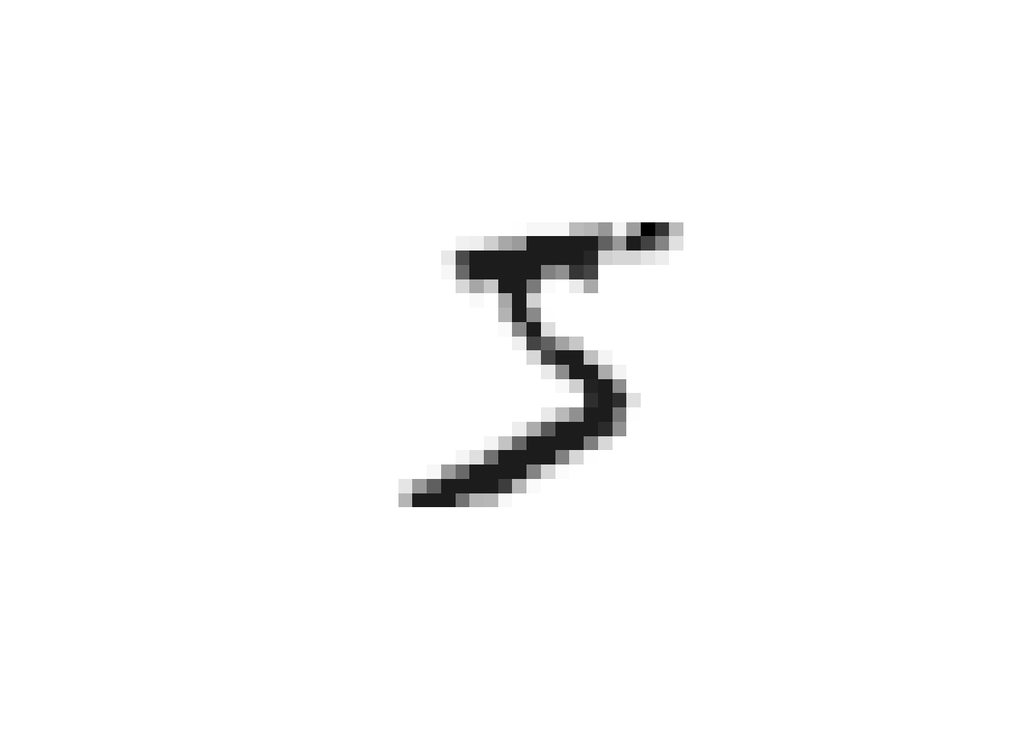

```r
plot_img <- function(img, col = gray.colors(255, start = 1, end = 0), ...) {
  image(t(img), asp = 1, ylim = c(1.1, -0.1), col = col, bty = "n", axes = FALSE, ...)
}

plot_img(mnist$train$x[1,,])
```

**3. As a preprocessing step, ensure the brightness values of the images in the training and test set are in the range (0, 1).**

```r
# to change the range from 0-255 to 0-1, we have to divide X by 255
mnist$train$x <- mnist$train$x / 255
mnist$test$x <- mnist$test$x / 255
```

## 2.2 Multinomial logistic regression

The simplest model is a multinomial logistic regression model, where we have no hidden layers and 10 outputs (0-1). That model is shown below.

**4. Display a summary of the multinomial model using the `summary()` function. Describe why this model has 7850 parameters.**

```r
multinom <-
  keras_model_sequential(input_shape = c(28, 28)) %>% # initialize a sequential model
  layer_flatten() %>% # flatten 28*28 matrix into single vector
  layer_dense(10, activation = "softmax") # softmax outcome == logistic regression for each of 10 outputs

multinom$compile(
  loss = "sparse_categorical_crossentropy", # loss function for multinomial outcome
  optimizer = "adam", # we use this optimizer because it works well
  metrics = list("accuracy") # we want to know training accuracy in the end
)
```

```r
summary(multinom)
```

```
Model: "sequential"
┌───────────────────────────────────┬──────────────────────────┬───────────────
│ Layer (type)                      │ Output Shape             │       Param #
├───────────────────────────────────┼──────────────────────────┼───────────────
│ flatten (Flatten)                 │ (None, 784)              │             0
├───────────────────────────────────┼──────────────────────────┼───────────────
│ dense (Dense)                     │ (None, 10)               │         7,850
└───────────────────────────────────┴──────────────────────────┴───────────────
 Total params: 7,850 (30.66 KB)
 Trainable params: 7,850 (30.66 KB)
 Non-trainable params: 0 (0.00 B)
```

The model has 7850 total parameters, because we have 28*28= 784 input features (pixels), which gives us the output shape for the flattening layer. Subsequently, we want an output shape of 10, which implies that for each of those 784 features, we have 10 weights (parameters), with an added 10 biases (intercepts) for each output shape, forming a total of 784*10+10 = 7850 parameters.

**5. Train the model for 5 epochs using the code below. What accuracy do we obtain in the validation set?** (NB: the multinom object is changed “in-place,” which means you don’t have to assign it to another variable.)

```r
set.seed(123)
multinom %>% fit(x = mnist$train$x, y = mnist$train$y, epochs = 5, validation_split = 0.2, verbose = 2)
```

```
1500/1500 - 3s - 2ms/step - accuracy: 0.8659 - loss: 0.5110 - val_accuracy: 0.9130 - val_loss: 0.3185
1500/1500 - 2s - 1ms/step - accuracy: 0.9112 - loss: 0.3175 - val_accuracy: 0.9201 - val_loss: 0.2891
1500/1500 - 2s - 1ms/step - accuracy: 0.9179 - loss: 0.2932 - val_accuracy: 0.9245 - val_loss: 0.2735
1500/1500 - 2s - 1ms/step - accuracy: 0.9213 - loss: 0.2815 - val_accuracy: 0.9254 - val_loss: 0.2742
1500/1500 - 2s - 1ms/step - accuracy: 0.9235 - loss: 0.2736 - val_accuracy: 0.9268 - val_loss: 0.2677
```

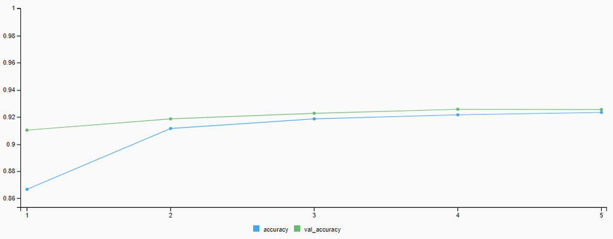

**6. Train the model for another 5 epochs. What accuracy do we obtain in the validation set?**

```r
set.seed(123)
multinom %>% fit(x = mnist$train$x, y = mnist$train$y, epochs = 5, validation_split = 0.2, verbose = 2)
```

```
1500/1500 - 2s - 1ms/step - accuracy: 0.9249 - loss: 0.2680 - val_accuracy: 0.9257 - val_loss: 0.2663
1500/1500 - 2s - 1ms/step - accuracy: 0.9268 - loss: 0.2636 - val_accuracy: 0.9248 - val_loss: 0.2675
1500/1500 - 2s - 1ms/step - accuracy: 0.9271 - loss: 0.2606 - val_accuracy: 0.9268 - val_loss: 0.2651
1500/1500 - 2s - 1ms/step - accuracy: 0.9281 - loss: 0.2574 - val_accuracy: 0.9296 - val_loss: 0.2618
1500/1500 - 2s - 1ms/step - accuracy: 0.9280 - loss: 0.2552 - val_accuracy: 0.9299 - val_loss: 0.2612
```

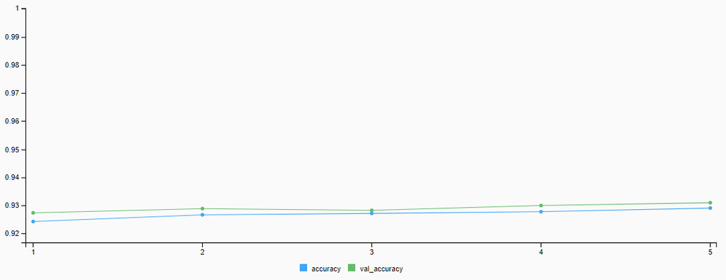

## 2.3 Deep feed-forward neural networks

**7. Create and compile a feed-forward neural network with the following properties. Ensure that the model has 50890 parameters.**

- Sequential model
- Flatten layer
- Dense layer with 64 hidden units and “relu” activation function
- Dense output layer with 10 units and softmax activation function

Then we have (784* 64 + 64) + (64 * 10 + 10) parameters

You may reuse code from the multinomial model.

```r
dffnn <- keras_model_sequential(input_shape = c(28, 28)) %>%
  layer_flatten() %>%
  layer_dense(64, activation = "relu") %>%
  layer_dense(10, activation = "softmax")

dffnn$compile(
  loss = "sparse_categorical_crossentropy",
  optimizer = "adam",
  metrics = list("accuracy")
)
```

```r
summary(dffnn)
```

```
Model: "sequential_1"
┌───────────────────────────────────┬──────────────────────────┬───────────────
│ Layer (type)                      │ Output Shape             │       Param #
├───────────────────────────────────┼──────────────────────────┼───────────────
│ flatten_1 (Flatten)               │ (None, 784)              │             0
├───────────────────────────────────┼──────────────────────────┼───────────────
│ dense_1 (Dense)                   │ (None, 64)               │        50,240
├───────────────────────────────────┼──────────────────────────┼───────────────
│ dense_2 (Dense)                   │ (None, 10)               │           650
└───────────────────────────────────┴──────────────────────────┴───────────────
 Total params: 50,890 (198.79 KB)
 Trainable params: 50,890 (198.79 KB)
 Non-trainable params: 0 (0.00 B)
```

**8. Train the model for 10 epochs. What do you see in terms of validation accuracy, also compared to the multinomial model?**

```r
dffnn %>% fit(x = mnist$train$x, y = mnist$train$y, epochs = 10, validation_split = 0.2, verbose = 2)
```

```
1500/1500 - 3s - 2ms/step - accuracy: 0.9049 - loss: 0.3344 - val_accuracy: 0.9473 - val_loss: 0.1868
1500/1500 - 3s - 2ms/step - accuracy: 0.9535 - loss: 0.1643 - val_accuracy: 0.9575 - val_loss: 0.1455
1500/1500 - 3s - 2ms/step - accuracy: 0.9655 - loss: 0.1202 - val_accuracy: 0.9630 - val_loss: 0.1231
1500/1500 - 3s - 2ms/step - accuracy: 0.9718 - loss: 0.0956 - val_accuracy: 0.9644 - val_loss: 0.1214
1500/1500 - 3s - 2ms/step - accuracy: 0.9766 - loss: 0.0783 - val_accuracy: 0.9672 - val_loss: 0.1070
1500/1500 - 3s - 2ms/step - accuracy: 0.9795 - loss: 0.0662 - val_accuracy: 0.9689 - val_loss: 0.1021
1500/1500 - 3s - 2ms/step - accuracy: 0.9830 - loss: 0.0552 - val_accuracy: 0.9681 - val_loss: 0.1098
1500/1500 - 3s - 2ms/step - accuracy: 0.9851 - loss: 0.0487 - val_accuracy: 0.9700 - val_loss: 0.1015
1500/1500 - 3s - 2ms/step - accuracy: 0.9872 - loss: 0.0414 - val_accuracy: 0.9684 - val_loss: 0.1081
1500/1500 - 3s - 2ms/step - accuracy: 0.9897 - loss: 0.0350 - val_accuracy: 0.9693 - val_loss: 0.1016
```

[figure not shown]

**9. Create predictions for the test data using the two trained models. Create a confusion matrix and compute test accuracy for these two models. Write down any observations you have.**

```r
class_predict <- function(model, x_train) predict(model, x = x_train) %>% apply(1, which.max) - 1
```

```r
pred_multinom <- class_predict(multinom, x = mnist$test$x)
```

```
313/313 - 0s - 789us/step
```

```r
pred_dffnn <- class_predict(dffnn, x = mnist$test$x)
```

```
313/313 - 0s - 898us/step
```

```r
(confus_multinom <- table(pred = pred_multinom, true = mnist$test$y))
```

```
    true
pred    0    1    2    3    4    5    6    7    8    9
   0  956    0    4    3    1    7    8    1    5    9
   1    0 1118   10    0    2    3    3    7   10    7
   2    0    3  920   20    4    3    4   23    6    1
   3    2    2   18  908    2   22    1    7   15    8
   4    0    0    9    1  923    7    7    9    9   31
   5    6    1    6   32    0  793   13    0   29    9
   6   12    4   15    2   10   15  919    0    9    0
   7    2    2    8   11    3    6    1  947   11   22
   8    2    5   39   26    9   31    2    2  876   10
   9    0    0    3    7   28    5    0   32    4  912
```

```r
(confus_dffnn <- table(pred = pred_dffnn, true = mnist$test$y))
```

```
    true
pred    0    1    2    3    4    5    6    7    8    9
   0  967    0    1    2    0    2    6    1    6    3
   1    1 1125    3    2    1    2    3    4    3    4
   2    3    3 1010    5    2    0    2    6    4    1
   3    1    1    4  984    1   11    0    8   13   10
   4    1    0    1    0  966    1    3    2    3    9
   5    1    1    0    7    0  865    2    0    9    9
   6    2    2    2    0    3    5  939    0    6    0
   7    1    0    7    4    3    1    1 1003    7    5
   8    2    3    4    3    1    4    2    1  921    4
   9    1    0    0    3    5    1    0    3    2  964
```

```r
(test_acc_multinom <- sum(diag(confus_multinom)) / sum(confus_multinom))
```

```
[1] 0.9272
```

```r
(test_acc_dffnn <- sum(diag(confus_dffnn)) / sum(confus_multinom))
```

```
[1] 0.9744
```

Similar to the validation accuracy results, we see substantially superior predictive performance on the test set by the DFFNN compared to the less deep multinomial model.

# 3 Lab exercises: convolutional neural network

Convolution layers in Keras need a specific form of data input. For each example, they need a `(width, height, channels)` array (tensor). For a colour image with 28*28 dimension, that shape is usually `(28, 28, 3)`, where the channels indicate red, green, and blue. MNIST has no colour info, but we still need the channel dimension to enter the data into a convolution layer with shape `(28, 28, 1)`. The training dataset `x_train` should thus have shape `(60000, 28, 28, 1)`.

**10. Add a “channel” dimension to the training and test data using the following code. Plot an image using the first channel of the 314th training example (this is a 9).**

```r
dim(mnist$train$x) <- c(dim(mnist$train$x), 1)
dim(mnist$test$x) <- c(dim(mnist$test$x), 1)
```

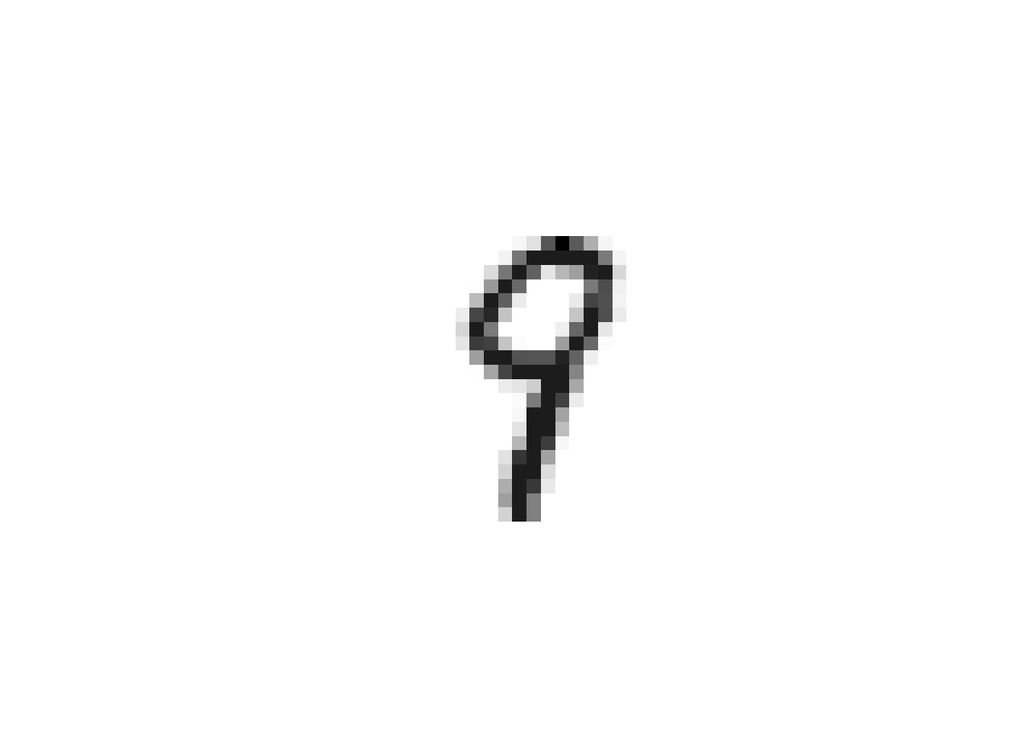

```r
plot_img(mnist$train$x[314,,,1])
```

**11. Create and compile a convolutional neural network using the following code. Describe the different layers in your own words.**

```r
cnn <-
  keras_model_sequential(input_shape = c(28, 28, 1)) %>%
  layer_conv_2d(filters = 6, kernel_size = c(5, 5)) %>%
  layer_max_pooling_2d(pool_size = c(4, 4)) %>%
  layer_flatten() %>%
  layer_dense(units = 32, activation = "relu") %>%
  layer_dense(10, activation = "softmax")

cnn %>%
  compile(
    loss = "sparse_categorical_crossentropy",
    optimizer = "adam",
    metrics = c("accuracy")
  )
```

```r
summary(cnn)
```

```
Model: "sequential_2"
┌───────────────────────────────────┬──────────────────────────┬───────────────
│ Layer (type)                      │ Output Shape             │       Param #
├───────────────────────────────────┼──────────────────────────┼───────────────
│ conv2d (Conv2D)                   │ (None, 24, 24, 6)        │           156
├───────────────────────────────────┼──────────────────────────┼───────────────
│ max_pooling2d (MaxPooling2D)      │ (None, 6, 6, 6)          │             0
├───────────────────────────────────┼──────────────────────────┼───────────────
│ flatten_2 (Flatten)               │ (None, 216)              │             0
├───────────────────────────────────┼──────────────────────────┼───────────────
│ dense_3 (Dense)                   │ (None, 32)               │         6,944
├───────────────────────────────────┼──────────────────────────┼───────────────
│ dense_4 (Dense)                   │ (None, 10)               │           330
└───────────────────────────────────┴──────────────────────────┴───────────────
 Total params: 7,430 (29.02 KB)
 Trainable params: 7,430 (29.02 KB)
 Non-trainable params: 0 (0.00 B)
```

The first layer is a convolutional layer with 6 filters, where each filter size is 5x5, implying that parameters are shared across these blocks. Subsequently, we have a pooling layer with max pool to reduce dimensionality of each of the 6 maps from 24x24 to 6x6, thus reducing their size by 4 in each direction. Then we flatten the array, after which there is a hidden dense layer with 32 units and ReLu activation function, followed by an output layer with 10 units and softmax activation function.

**12. Fit this model on the training data (10 epochs) and compare it to the previous models.**

```r
cnn %>% fit(x = mnist$train$x, y = mnist$train$y, epochs = 10, validation_split = 0.2, verbose = 2)
```

```
1500/1500 - 4s - 3ms/step - accuracy: 0.8926 - loss: 0.3752 - val_accuracy: 0.9562 - val_loss: 0.1553
1500/1500 - 3s - 2ms/step - accuracy: 0.9611 - loss: 0.1317 - val_accuracy: 0.9701 - val_loss: 0.1035
1500/1500 - 4s - 2ms/step - accuracy: 0.9720 - loss: 0.0941 - val_accuracy: 0.9757 - val_loss: 0.0810
1500/1500 - 4s - 2ms/step - accuracy: 0.9772 - loss: 0.0759 - val_accuracy: 0.9753 - val_loss: 0.0796
1500/1500 - 4s - 2ms/step - accuracy: 0.9809 - loss: 0.0636 - val_accuracy: 0.9789 - val_loss: 0.0673
1500/1500 - 4s - 2ms/step - accuracy: 0.9830 - loss: 0.0561 - val_accuracy: 0.9796 - val_loss: 0.0662
1500/1500 - 4s - 2ms/step - accuracy: 0.9841 - loss: 0.0503 - val_accuracy: 0.9797 - val_loss: 0.0656
1500/1500 - 3s - 2ms/step - accuracy: 0.9858 - loss: 0.0459 - val_accuracy: 0.9818 - val_loss: 0.0623
1500/1500 - 3s - 2ms/step - accuracy: 0.9868 - loss: 0.0412 - val_accuracy: 0.9803 - val_loss: 0.0645
1500/1500 - 3s - 2ms/step - accuracy: 0.9876 - loss: 0.0388 - val_accuracy: 0.9814 - val_loss: 0.0649
```

```r
pred_cnn <- class_predict(cnn, x = mnist$test$x)
```

```
313/313 - 0s - 1ms/step
```

```r
(confus_cnn <- table(pred = pred_cnn, true = mnist$test$y))
```

```
    true
pred    0    1    2    3    4    5    6    7    8    9
   0  971    0    1    0    0    1    2    1    8    3
   1    0 1127    2    0    2    0    2    1    0    2
   2    1    2 1013    4    2    1    0    9    2    0
   3    1    1    8  998    0    5    0    8   10   11
   4    1    0    1    0  965    0    4    0    2    5
   5    2    1    0    5    0  878    2    2    3    5
   6    1    3    0    0    0    4  946    0    5    1
   7    2    1    2    0    0    0    0 1001    2    4
   8    0    0    4    1    3    0    2    0  936    7
   9    1    0    1    2   10    3    0    6    6  971
```

```r
sum(diag(confus_cnn)) / sum(confus_cnn)
```

```
[1] 0.9806
```

[figure not shown]

**13. Create another CNN which has better validation performance within 10 epochs. Compare your validation accuracy to that of your peers.**

```r
improved_cnn <-
  keras_model_sequential(input_shape = c(28, 28, 1)) %>%
  layer_conv_2d(filters = 8, kernel_size = c(3, 3), activation = "relu") %>%
  layer_max_pooling_2d(pool_size = c(2, 2)) %>%
  layer_conv_2d(filters = 16, kernel_size = c(3, 3), activation = "relu") %>%
  layer_max_pooling_2d(pool_size = c(2, 2)) %>%
  layer_flatten() %>%
  layer_dropout(0.5) %>%
  layer_dense(units = 64, activation = "relu") %>%
  layer_dense(10, activation = "softmax")

improved_cnn %>%
  compile(
    loss = "sparse_categorical_crossentropy",
    optimizer = "adam",
    metrics = c("accuracy")
  )

improved_cnn %>% fit(x = mnist$train$x, y = mnist$train$y, epochs = 10, validation_split = 0.2, verbose = 2)
```

```
1500/1500 - 6s - 4ms/step - accuracy: 0.8721 - loss: 0.3973 - val_accuracy: 0.9658 - val_loss: 0.1142
1500/1500 - 5s - 3ms/step - accuracy: 0.9464 - loss: 0.1714 - val_accuracy: 0.9754 - val_loss: 0.0834
1500/1500 - 5s - 3ms/step - accuracy: 0.9569 - loss: 0.1361 - val_accuracy: 0.9803 - val_loss: 0.0692
1500/1500 - 5s - 3ms/step - accuracy: 0.9637 - loss: 0.1139 - val_accuracy: 0.9843 - val_loss: 0.0559
1500/1500 - 5s - 3ms/step - accuracy: 0.9671 - loss: 0.1032 - val_accuracy: 0.9858 - val_loss: 0.0503
1500/1500 - 5s - 3ms/step - accuracy: 0.9703 - loss: 0.0945 - val_accuracy: 0.9859 - val_loss: 0.0494
1500/1500 - 5s - 3ms/step - accuracy: 0.9724 - loss: 0.0880 - val_accuracy: 0.9872 - val_loss: 0.0469
1500/1500 - 5s - 3ms/step - accuracy: 0.9733 - loss: 0.0846 - val_accuracy: 0.9867 - val_loss: 0.0466
1500/1500 - 5s - 3ms/step - accuracy: 0.9756 - loss: 0.0765 - val_accuracy: 0.9868 - val_loss: 0.0449
1500/1500 - 5s - 3ms/step - accuracy: 0.9760 - loss: 0.0746 - val_accuracy: 0.9892 - val_loss: 0.0365
```

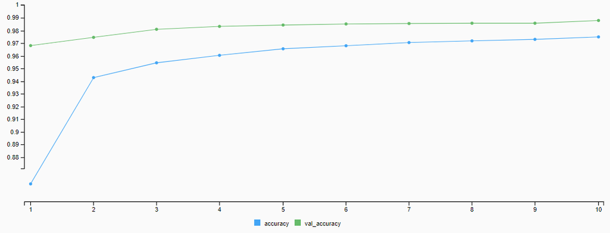

```r
pred_cnn_imp <- class_predict(improved_cnn, x = mnist$test$x)
```

```
313/313 - 0s - 1ms/step
```

```r
(confus_cnn_imp <- table(pred = pred_cnn_imp, true = mnist$test$y))
```

```
    true
pred    0    1    2    3    4    5    6    7    8    9
   0  975    0    1    0    0    1    5    0    1    2
   1    0 1133    1    0    0    0    2    3    0    1
   2    1    2 1024    3    0    0    0    8    3    2
   3    0    0    0 1000    0    8    0    3    3    2
   4    0    0    0    0  976    0    1    0    0    3
   5    0    0    0    3    0  878    5    0    0    2
   6    1    0    0    0    0    1  944    0    0    0
   7    2    0    3    2    2    1    0 1008    1    6
   8    1    0    3    2    0    1    1    2  963    4
   9    0    0    0    0    4    2    0    4    3  987
```

```r
sum(diag(confus_cnn_imp)) / sum(confus_cnn_imp)
```

```
[1] 0.9888
```